# meth04_regional_analysis

# Regional DNA methylation analysis using DMRcate

Using data preprocessed in our script: meth01_process_data.R

```r
options(warn=-1)
suppressMessages(library(data.table))
suppressMessages(library(stringi))
suppressMessages(library(limma))
suppressMessages(library(minfi))
suppressMessages(library(missMethyl))
suppressMessages(library(ChAMP))
suppressMessages(library(IlluminaHumanMethylationEPICv2anno.20a1.hg38))
options(warn=0)
```

load the data

```r
load("./data/processed.rda")
```

### Introduction to differential variability analysis

see [Phipson and Oshlack. Genome Biol 2014](https://pubmed.ncbi.nlm.nih.gov/25245051/).  
Impute missing Beta-values (varFit will produce an error with missingness)

```r
sum(is.na(beta))
```

```
## [1] 169711
```

the champ.impute function prints a lot of information when running, so we’ll use this function to suppress the progress messages

```r
hush=function(code){
  sink("NUL") # use /dev/null in UNIX
  tmp = code
  sink()
  return(tmp)
}
betas.impute <- hush(champ.impute(beta=beta, pd=pheno, k=5, ProbeCutoff=0.2, SampleCutoff=0.1))
```

```
## [===========================]
```

```
## [<<< ChAMP.IMPUTE START >>>>]
```

```
## <method>:Combine. (Suitable for Large Data Set)
```

```
## (1): 0 Samples contain 0.1 or above NA will be removed.
```

```
## (2): 8384 Probes contain 0.2 or above NA will be removed.
```

```
## (3): The rest NA are imputed by KNN method which parameter k as 5.
```

```
## [<<<<< ChAMP.IMPUTE END >>>>]
```

```
## [===========================]
```

```r
betas.impute <- betas.impute$beta
```

coef parameter in varFit states which columns of design matrix correspond to the intercept and variable of interest  
If Beta-values are used, a lofit transformation is performed within the varFit function

```r
model <- model.matrix( ~smoker+Sex+CD4+CD8+NK+B+MO,data=pheno)
head(model)
```

```
##   (Intercept) smoker Sexm       CD4        CD8         NK          B         MO
## 1           1      1    1 0.1505541 0.06503963 0.06623331 0.08400697 0.05112252
## 2           1      1    1 0.2145401 0.03343239 0.06787113 0.15027916 0.07434410
## 3           1      1    0 0.1841988 0.06863253 0.04309029 0.08432918 0.07463714
## 4           1      1    1 0.1124693 0.03452843 0.06559924 0.06818187 0.06271118
## 5           1      1    0 0.2362087 0.04334008 0.05618664 0.10681466 0.04510075
## 6           1      1    1 0.1296804 0.18252709 0.05299009 0.08620063 0.09461704
```

```r
EWAS.diffVar <- varFit(betas.impute, design=model, coef=c(1,2))
Top.diffVar <- topVar(EWAS.diffVar, coef=2, number=10, sort =TRUE)
Top.diffVar
```

```
##              SampleVar LogVarRatio DiffLevene         t      P.Value
## cg03459282 0.224613506   -3.466854 -0.5931358 -5.860754 4.587493e-08
## cg04715529 0.344871915   -3.202302 -0.7448446 -5.610851 2.377490e-07
## cg23396486 0.401654000   -2.722713 -0.7774213 -5.150850 1.101279e-06
## cg21083467 0.285870845   -2.767801 -0.6440091 -5.145492 1.127065e-06
## cg04300100 0.008568052   -2.129945 -0.1160706 -5.062907 1.607463e-06
## cg24758122 0.345290506    4.283485  0.6318778  5.017966 1.947400e-06
## cg21526544 0.319763634    3.667042  0.5829660  4.965416 2.434084e-06
## cg19712474 0.281506171   -1.887376 -0.6487578 -4.928785 2.841316e-06
## cg22814936 0.446680309   -3.615039 -0.7759387 -4.931655 2.970679e-06
## cg01468161 0.334922543    4.414542  0.6569477  4.838677 8.136702e-06
##            Adj.P.Value
## cg03459282  0.04070331
## cg04715529  0.10547341
## cg23396486  0.25000191
## cg21083467  0.25000191
## cg04300100  0.28524982
## cg24758122  0.28797723
## cg21526544  0.29286501
## cg19712474  0.29286501
## cg22814936  0.29286501
## cg01468161  0.64358921
```

Bind results with annotation

```r
Annot <- as.data.frame(getAnnotation(IlluminaHumanMethylationEPICv2anno.20a1.hg38))
Annot <- subset(Annot, Annot$Name %in% manifest$ilmn_id)
Annot$ID <- substr(Annot$Name, 1, 10)
Top.diffVar$ID <- row.names(Top.diffVar)
Top.diffVar <- dplyr::left_join(Top.diffVar, Annot, by = "ID")
```

Order by chr and chromosomal position

```r
Top.diffVar$chr <- as.numeric(gsub("chr", "", Top.diffVar$chr))
Top.diffVar[,c(2,6)] <- round(Top.diffVar[,c(2,6)],2)
Top.diffVar[order(Top.diffVar$chr, Top.diffVar$pos),c(2,5,7,8,9)]
```

```
##    LogVarRatio      P.Value         ID chr       pos
## 1        -3.47 4.587493e-08 cg03459282   2 126938662
## 5        -2.13 1.607463e-06 cg04300100   2 233424599
## 2        -3.20 2.377490e-07 cg04715529   3  32369625
## 8        -1.89 2.841316e-06 cg19712474   5  33712513
## 4        -2.77 1.127065e-06 cg21083467   6   3076807
## 10        4.41 8.136702e-06 cg01468161   7  15855614
## 3        -2.72 1.101279e-06 cg23396486   7 142771880
## 7         3.67 2.434084e-06 cg21526544  16  55036247
## 9        -3.62 2.970679e-06 cg22814936  17  64334251
## 6         4.28 1.947400e-06 cg24758122  19  53007392
```

We can see differences in variability among the top sites

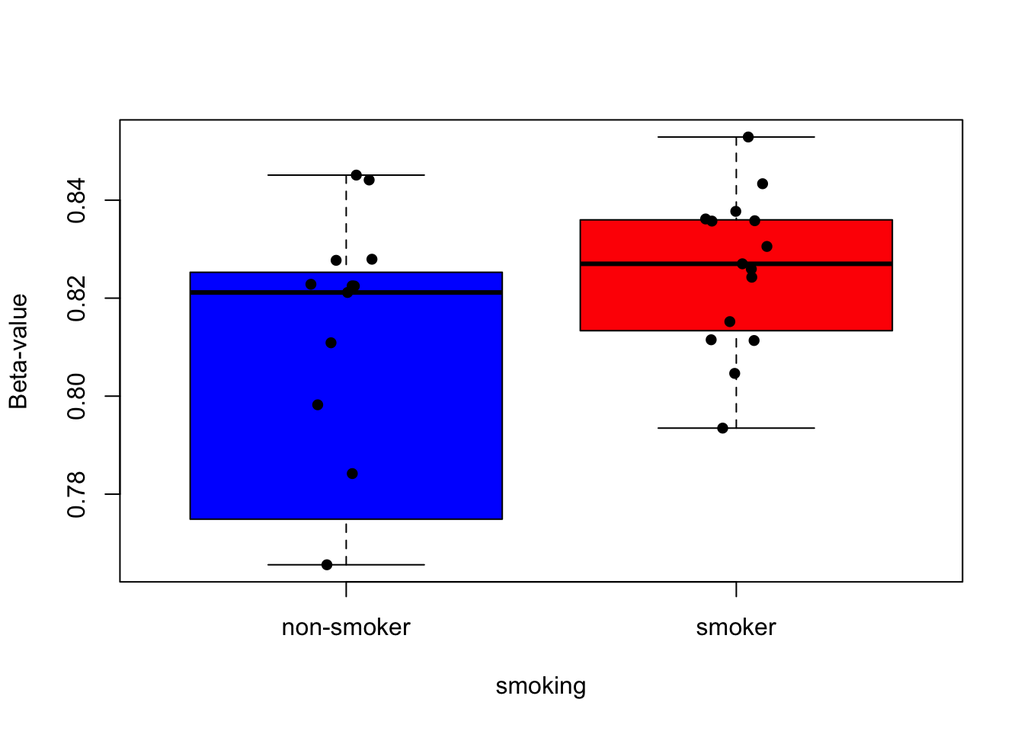

```r
cpg1 <- data.frame(id = colnames(betas.impute), beta = betas.impute[rownames(betas.impute) == 'cg03459282',])
cpg1 <- merge(cpg1, pheno[,c('gsm', 'smoker')], by.x = 'id', by.y = 'gsm')
cpg1$smoker <- as.numeric(factor(cpg1$smoker))

cpg2 <- data.frame(id = colnames(betas.impute), beta = betas.impute[rownames(betas.impute) == 'cg04300100',])
cpg2 <- merge(cpg2, pheno[,c('gsm', 'smoker')], by.x = 'id', by.y = 'gsm')
cpg2$smoker <- as.numeric(factor(cpg2$smoker))

boxplot(cpg1$beta ~ cpg1$smoker, col = c("blue", "red"), outline = F, xlab = 'smoking', ylab = 'Beta-value', names = c("non-smoker", "smoker"));points(jitter(cpg1$smoker, amount = 0.1), cpg1$beta, pch = 16)
```

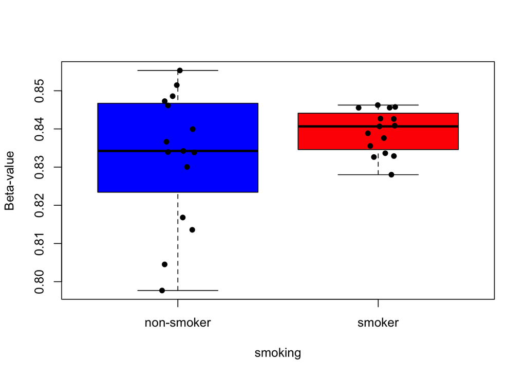

```r
boxplot(cpg2$beta ~ cpg2$smoker, col = c("blue", "red"), outline = F, xlab = 'smoking', ylab = 'Beta-value', names = c("non-smoker", "smoker"));points(jitter(cpg2$smoker, amount = 0.1), cpg2$beta, pch = 16)
```

Note that diffVar results may be influenced by outliers, and therefore it is helpful to visually inspect results.

```r
rm(Top.diffVar,EWAS.diffVar,betas.impute,cpg1,cpg2);gc()
```

```
##             used   (Mb) gc trigger   (Mb) limit (Mb)  max used   (Mb)
## Ncells  28119876 1501.8   51124291 2730.4         NA  51124291 2730.4
## Vcells 423711887 3232.7  923863150 7048.6      65536 923863150 7048.6
```

## Introduction to regional analyses with DMRcate

```r
suppressMessages(library(DMRcate)) # Popular package for regional DNA methylation analysis
```

Let’s run the regional analysis using the Beta-values from our preprocessed data  
First reorder matrix and revert to EPICv2 probe names

```r
beta <- beta[manifest$probe_id, ]
row.names(beta) <- manifest$ilmn_id
```

You may receive a prompt to create AnnotationHub directory. Enter ‘yes’ in console to proceed

```r
myannotation <- cpg.annotate("array", na.omit(beta), analysis.type="differential",arraytype="EPICv2",
                             epicv2Filter = "mean",
                             what="Beta",design=model, coef=2)
```

```
## EPICv2 specified. Loading manifest...
```

```
## loading from cache
```

```
## Remapping 11412 cross-hybridising probes to their more likely offtarget...
```

```
## Replicate probes that map to the same CpG site found. Filtering these using strategy: mean
```

```
## Averaging probes that map to the same CpG site...
```

```
## Your contrast returned 22 individually significant probes; a small but real effect. Consider manually setting the value of pcutoff to return more DMRs, but be warned that doing this increases the risk of Type I errors.
```

set analysis.type = “diffVar” to return differentially variable methylated regions  
DMRcate needs complete data. We can use na.omit() to remove rows with missing data or use the betas.impute object  
DMRcate uses the a different annotation and remaps probes with possible off-targets; therefore, some position replicates are merged

Regions are now agglomerated from groups of significant probes where the distance to the next consecutive probe is less than lambda nucleotides away

```r
dmrcoutput.smoking <- dmrcate(myannotation, lambda=1000, C=2)
```

```
## Fitting chr1...
```

```
## Fitting chr2...
```

```
## Fitting chr3...
```

```
## Fitting chr4...
```

```
## Fitting chr5...
```

```
## Fitting chr6...
```

```
## Fitting chr7...
```

```
## Fitting chr8...
```

```
## Fitting chr9...
```

```
## Fitting chr10...
```

```
## Fitting chr11...
```

```
## Fitting chr12...
```

```
## Fitting chr13...
```

```
## Fitting chr14...
```

```
## Fitting chr15...
```

```
## Fitting chr16...
```

```
## Fitting chr17...
```

```
## Fitting chr18...
```

```
## Fitting chr19...
```

```
## Fitting chr20...
```

```
## Fitting chr21...
```

```
## Fitting chr22...
```

```
## Fitting chrX...
```

```
## Fitting chrY...
```

```
## Fitting chrM...
```

```
## Demarcating regions...
```

```
## Done!
```

Let’s look at the results

```r
results.ranges <- extractRanges(dmrcoutput.smoking, genome = "hg38")
```

```
## see ?DMRcatedata and browseVignettes('DMRcatedata') for documentation
```

```
## downloading 1 resources
```

```
## retrieving 1 resource
```

```
## loading from cache
```

```r
results.ranges
```

```
## GRanges object with 5 ranges and 8 metadata columns:
##       seqnames              ranges strand |   no.cpgs min_smoothed_fdr
##          <Rle>           <IRanges>  <Rle> | <integer>        <numeric>
##   [1]     chr2 232419402-232420744      * |         4      2.73370e-56
##   [2]     chr5       373263-373772      * |         2      3.63518e-54
##   [3]     chr7   44962513-44963381      * |         6      5.67214e-39
##   [4]     chr1   92481143-92482404      * |         6      1.00965e-30
##   [5]     chr5       395329-395602      * |         2      7.20598e-29
##          Stouffer       HMFDR      Fisher    maxdiff   meandiff
##         <numeric>   <numeric>   <numeric>  <numeric>  <numeric>
##   [1] 1.05763e-17 2.39410e-10 9.56781e-22 -0.2477809 -0.1119718
##   [2] 2.23823e-06 2.12539e-12 6.34433e-12 -0.3501259 -0.1758337
##   [3] 2.66988e-20 2.88957e-07 9.56781e-22  0.2303215  0.1378339
##   [4] 7.11263e-23 6.49907e-07 9.56781e-22 -0.1604499 -0.1047282
##   [5] 1.04819e-06 2.39410e-10 4.97817e-10 -0.0982509 -0.0527546
##         overlapping.genes
##               <character>
##   [1] ECEL1P1, AC068134.2
##   [2]    PDCD6-AHRR, AHRR
##   [3]               MYO1G
##   [4]                GFI1
##   [5]    PDCD6-AHRR, AHRR
##   -------
##   seqinfo: 4 sequences from an unspecified genome; no seqlengths
```

Plot the DMR using the Gviz  
If you are interested in plotting genomic data the Gviz is extremely useful

```r
results.ranges[2]
```

```
## GRanges object with 1 range and 8 metadata columns:
##       seqnames        ranges strand |   no.cpgs min_smoothed_fdr    Stouffer
##          <Rle>     <IRanges>  <Rle> | <integer>        <numeric>   <numeric>
##   [1]     chr5 373263-373772      * |         2      3.63518e-54 2.23823e-06
##             HMFDR      Fisher   maxdiff  meandiff overlapping.genes
##         <numeric>   <numeric> <numeric> <numeric>       <character>
##   [1] 2.12539e-12 6.34433e-12 -0.350126 -0.175834  PDCD6-AHRR, AHRR
##   -------
##   seqinfo: 4 sequences from an unspecified genome; no seqlengths
```

set up the grouping variables and colours

```r
pheno$smoker<-as.factor(pheno$smoker)
cols = c("magenta","red")[pheno$smoker]
names(cols) = levels(pheno$smoker)[pheno$smoker]
```

Draw the plot a DMR

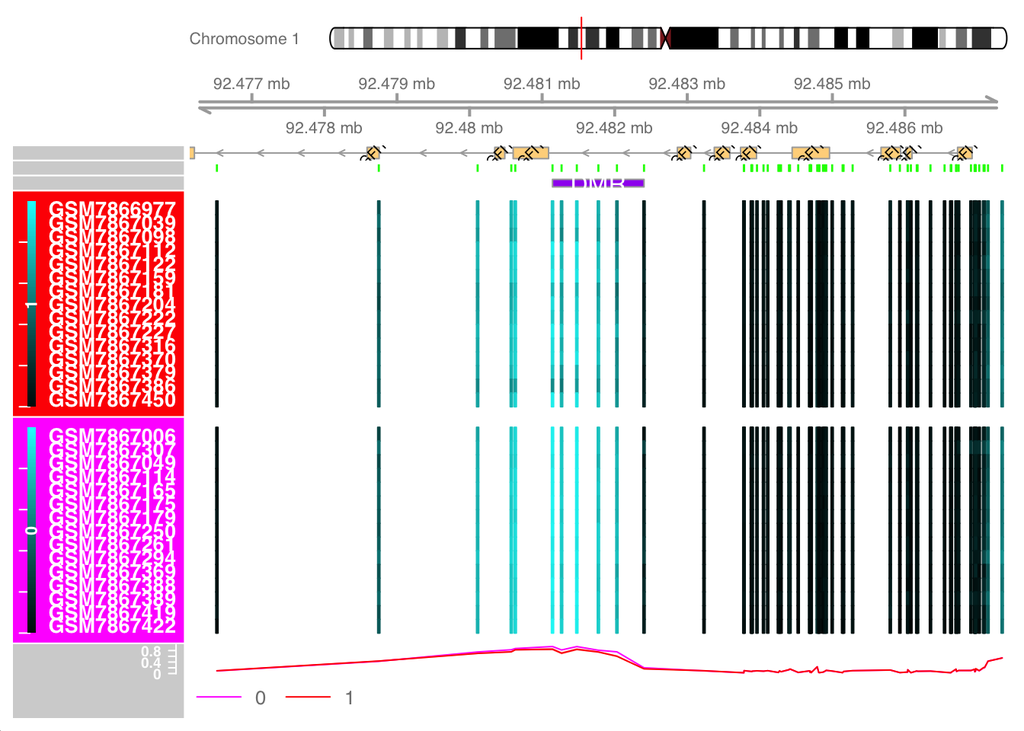

```r
DMR.plot(ranges=results.ranges, dmr=4, CpGs=beta, phen.col=cols, what = "Beta",
         arraytype = "EPICv2", genome="hg38")
```

Clean data

```r
rm(dmrcoutput.smoking,myannotation);gc()
```

```
##             used   (Mb) gc trigger   (Mb) limit (Mb)   max used   (Mb)
## Ncells  28431733 1518.5   51124291 2730.4         NA   51124291 2730.4
## Vcells 434927571 3318.3 1108715780 8458.9      65536 1108494569 8457.2
```

# Introduction to regional analyses with comb-p

See [Pedersen et al. Bioinformatics 2012](https://academic.oup.com/bioinformatics/article/28/22/2986/240603).

```r
suppressMessages(library(ENmix))
```

Reload beta matrix with legacy probe names

```r
load("./data/processed.rda")
```

Input is a data frame with colnames “chr”, “start”, “end”, “p” and “probe”  
Using p-values from limma

```r
EWAS.limma <- eBayes(lmFit(beta, design=model))
EWAS.limma <- topTable(EWAS.limma, coef=2, number=Inf, sort.by="p")
EWAS.limma <- EWAS.limma[!is.na(EWAS.limma$logFC),]
```

Add chr and pos

```r
EWAS.limma <- cbind(EWAS.limma, chr = Annot[,"chr"][match(rownames(EWAS.limma), Annot$ID)])
EWAS.limma <- cbind(EWAS.limma, pos = Annot[,"pos"][match(rownames(EWAS.limma), Annot$ID)])
EWAS.limma$chr <- as.numeric(gsub("chr", "", EWAS.limma$chr)) # chr as numeric
EWAS.limma$end <- EWAS.limma$pos
```

keep only needed columns

```r
EWAS.combp <- EWAS.limma[,c("chr", "pos", "end", "P.Value")]
colnames(EWAS.combp) <- c("chr", "start", "end", "p")
EWAS.combp$probe = rownames(EWAS.combp)
```

Run combp. Results saved in working directory. For efficiency, we’ll use output already generated.

```r
combp(EWAS.combp, region_plot = F, mht_plot = F, dist.cutoff=1000, seed=0.001, verbose = T)
```

dist.cutoff = maximum distrance between basepairs to combine adjacent DMRs;  
seed = FDR significance threshold for initial selection of DMRs

read output

```r
combp.result = read.csv('./results/resu_combp.csv')
combp.result[1:5, ]
```

```
##   chr     start       end            p          fdr        sidak nprobe
## 1   2 232419950 232420224 1.167578e-17 3.269218e-16 0.000000e+00      2
## 2   7  44962886  44963381 3.582210e-15 5.015094e-14 6.419310e-12      4
## 3   5    373262    373263 3.312250e-13 3.091434e-12 2.962099e-07      1
## 4   1  92481267  92482031 8.370664e-13 5.859465e-12 9.799962e-10      4
## 5  15  90872581  90872888 5.815319e-11 3.256579e-10 1.694225e-07      7
##                                                                          probe
## 1                                                        cg21566642;cg01940273
## 2                                  cg22132788;cg12803068;cg05009104;cg04180046
## 3                                                                   cg05575921
## 4                                  cg09935388;cg12876356;cg18316974;cg04535902
## 5 cg07162861;cg05466844;cg10698959;cg12722937;cg23662846;cg04791659;cg00207731
```

comb-p has higher power to detect small effect sizes, but increased Type I error  
See [Malid et al. Briefings in Bioinformatics 2019](https://academic.oup.com/bib/article/20/6/2224/5096828)

Other popular options for conducting Regional DNA methylation analysis in R are Aclust and bumphunter

Visualizing DMPs and DMRs using EWASplot

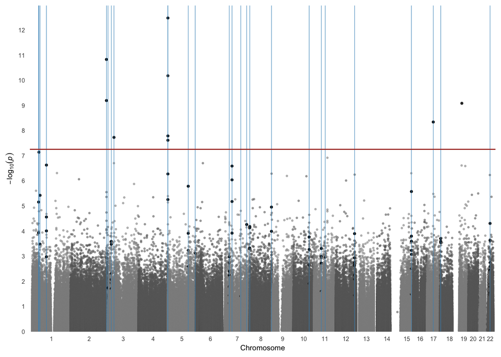

```r
suppressMessages(library(ggplot2))
suppressMessages(library(EWASplot))
manhattan_plot(probe = EWAS.limma, region = combp.result)
```

clear environment

```r
rm(list = ls()); gc()
```

```
##             used   (Mb) gc trigger   (Mb) limit (Mb)   max used   (Mb)
## Ncells  28634283 1529.3   51124291 2730.4         NA   51124291 2730.4
## Vcells 385112760 2938.2 1108715780 8458.9      65536 1108494569 8457.2
```